# tidyverse_grouping&summarizing

Manojit Sarkar

19 July 2018

In this chapter we will dive back into more of “dplyr” verbs as we dis in the Data Wrangling

## 1)summarise() verb which turns many observations into one

Before that as usal lets install and load the libaries

```r
library(tidyverse)
library(gapminder)
```

So , lets start with the average life expectancy

```r
gapminder%>%
  summarize(meanLifeExp=mean(lifeExp))
```

```
## # A tibble: 1 x 1
##   meanLifeExp
##         <dbl>
## 1        59.5
```

the summarize() collapses the entire table into one row.

It doesnt make a sense to do the average life expectancy for all the years and across all countries .. so lets take the year 2007 and find out the average life expectancy over all the countries.

```r
gapminder%>%
  filter(year==2007)%>%
  summarise(lifeMeanExp=mean(lifeExp))
```

```
## # A tibble: 1 x 1
##   lifeMeanExp
##         <dbl>
## 1        67.0
```

We can use multiple summarize at time. lets find out the total population for 2007 along with the average life expectancy.

```r
gapminder%>%
  filter(year==2007)%>%
  summarise(lifeMeanExp=mean(lifeExp),totalPop=sum(as.numeric(pop)))
```

```
## # A tibble: 1 x 2
##   lifeMeanExp   totalPop
##         <dbl>      <dbl>
## 1        67.0 6251013179
```

note :- as.numeric converts the integer valuse into numeric.

let dive into more summarize built in functions..

1)lets use median() function for the year 1957 on the lifeExp

```r
gapminder%>%
  filter(year==1957)%>%
  summarise(medianLifeExp=median(lifeExp))
```

```
## # A tibble: 1 x 1
##   medianLifeExp
##           <dbl>
## 1          48.4
```

2)Filter for 1957 then summarize the median life expectancy and the maximum GDP per capita

```r
gapminder%>%
  filter(year==1957)%>%
  summarise(medianLifeExp=median(lifeExp),maxGDPperCap=max(gdpPercap))
```

```
## # A tibble: 1 x 2
##   medianLifeExp maxGDPperCap
##           <dbl>        <dbl>
## 1          48.4      113523.
```

## 2) group_by() verb group_by before summarise() turns groups into one row.

lets see an example

```r
gapminder%>%
  group_by(year)%>%
  summarise(meanLifeExp=mean(lifeExp),totalpop=sum(as.numeric(pop)))
```

```
## # A tibble: 12 x 3
##     year meanLifeExp   totalpop
##    <int>       <dbl>      <dbl>
##  1  1952        49.1 2406957150
##  2  1957        51.5 2664404580
##  3  1962        53.6 2899782974
##  4  1967        55.7 3217478384
##  5  1972        57.6 3576977158
##  6  1977        59.6 3930045807
##  7  1982        61.5 4289436840
##  8  1987        63.2 4691477418
##  9  1992        64.2 5110710260
## 10  1997        65.0 5515204472
## 11  2002        65.7 5886977579
## 12  2007        67.0 6251013179
```

now lets check the average life expectancy and pop within each continent in the year 2007–

```r
gapminder%>%
  filter(year==2007)%>%
  group_by(continent)%>%
  summarise(meanLifeExp=mean(lifeExp),totalPop=sum(as.numeric(pop)))
```

```
## # A tibble: 5 x 3
##   continent meanLifeExp   totalPop
##   <fct>           <dbl>      <dbl>
## 1 Africa           54.8  929539692
## 2 Americas         73.6  898871184
## 3 Asia             70.7 3811953827
## 4 Europe           77.6  586098529
## 5 Oceania          80.7   24549947
```

The average life expecantancy is high for oceania followed by Europe with total pop highest for Asia followed by Africa.

now lets see how these values change over time :-

```r
gapminder%>%
  group_by(year,continent)%>%
  summarise(meanLifeExp=mean(lifeExp),totalPop=sum(as.numeric(pop)))
```

```
## # A tibble: 60 x 4
## # Groups:   year [?]
##     year continent meanLifeExp   totalPop
##    <int> <fct>           <dbl>      <dbl>
##  1  1952 Africa           39.1  237640501
##  2  1952 Americas         53.3  345152446
##  3  1952 Asia             46.3 1395357351
##  4  1952 Europe           64.4  418120846
##  5  1952 Oceania          69.3   10686006
##  6  1957 Africa           41.3  264837738
##  7  1957 Americas         56.0  386953916
##  8  1957 Asia             49.3 1562780599
##  9  1957 Europe           66.7  437890351
## 10  1957 Oceania          70.3   11941976
## # ... with 50 more rows
```

cool!!

Lets now visualize the above 2 datas using a scatterplot

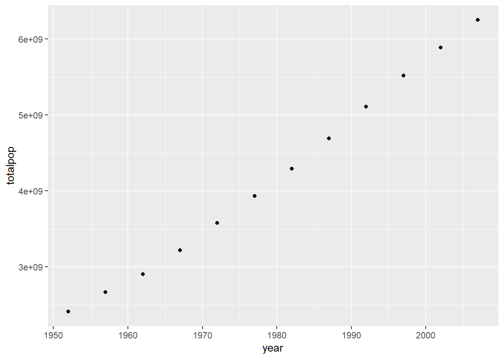

```r
by_year<-gapminder%>%
  group_by(year)%>%
  summarise(meanLifeExp=mean(lifeExp),totalpop=sum(as.numeric(pop)))

#visualisation part

ggplot(by_year,aes(x=year,y=totalpop))+geom_point()
```

Notice that the Y axis doesnt start with zero its time for us to introduce a new graphing option “expands_limits(y=0)”

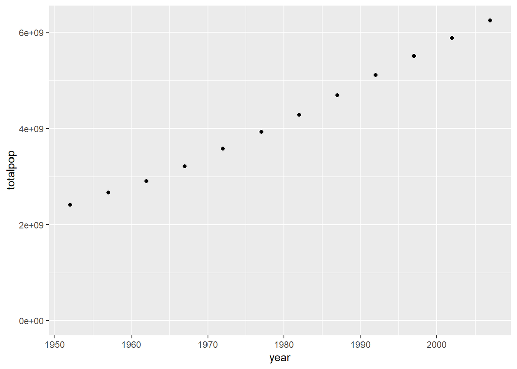

```r
by_year<-gapminder%>%
  group_by(year)%>%
  summarise(meanLifeExp=mean(lifeExp),totalpop=sum(as.numeric(pop)))

#visualisation part

ggplot(by_year,aes(x=year,y=totalpop))+geom_point()+expand_limits(y=0)
```

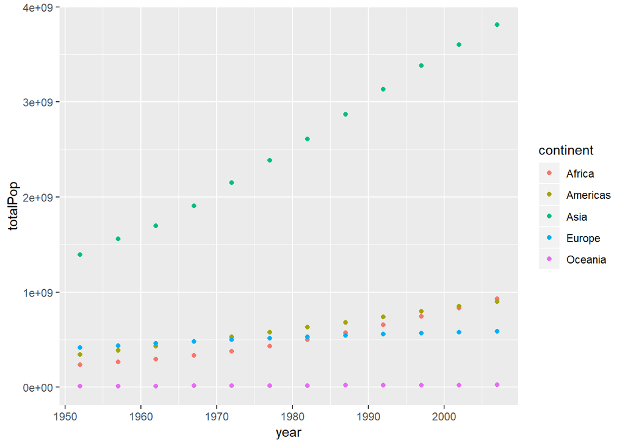

```r
by_year_continent<-gapminder%>%
  group_by(year,continent)%>%
  summarise(meanLifeExp=mean(lifeExp),totalPop=sum(as.numeric(pop)))
#visualization part

ggplot(by_year_continent,aes(y=totalPop,x=year,color=continent))+geom_point()+expand_limits(y=0)
```

This is it for Grouping and Summarizing !!! May the force be with You !! We are one with the force and the force is one with us !!!